# Data Camp Python Programming

Example code includes:

```python
# Import necessary modules
import matplotlib.pyplot as plt
import networkx as nx
import numpy as np
import random


# DO NOT HAVE Github collaborator graph "G"
# Dummy up the data - 20 each of 2 "flavors"
G = nx.Graph()
G.add_nodes_from([x for x in range(1, 41)])
np.random.seed(170531)

# Add edges for 1-20 with preference that they match to themselves
n1 = np.random.choice(range(1, 21), size=100, replace=True)
n2 = np.random.choice(range(1, 21), size=90, replace=True)
n3 = np.random.choice(range(21, 41), size=10, replace=True)

# Require that first be less than second
edge_list = [(min(x, y), max(x, y)) for x, y in zip(n1, np.append(n2, n3)) if x != y]
G.add_edges_from(edge_list)


# Add edges for 21-40 with preference that they match to themselves
n1 = np.random.choice(range(21, 41), size=50, replace=True)
n2 = np.random.choice(range(21, 41), size=40, replace=True)
n3 = np.random.choice(range(1, 21), size=10, replace=True)

# Require that first be less than second
edge_list = [(min(x, y), max(x, y)) for x, y in zip(n1, np.append(n2, n3)) if x != y]
G.add_edges_from(edge_list)

# Create two groupings for the nodes
node_meta = [{'grouping': 'type01'}, {'grouping': 'type01'}, {'grouping': 'type01'}, {'grouping': 'type01'}, {'grouping': 'type01'}, {'grouping': 'type01'}, {'grouping': 'type01'}, {'grouping': 'type01'}, {'grouping': 'type01'}, {'grouping': 'type01'}, {'grouping': 'type01'}, {'grouping': 'type01'}, {'grouping': 'type01'}, {'grouping': 'type01'}, {'grouping': 'type01'}, {'grouping': 'type01'}, {'grouping': 'type01'}, {'grouping': 'type01'}, {'grouping': 'type01'}, {'grouping': 'type01'}, {'grouping': 'type02'}, {'grouping': 'type02'}, {'grouping': 'type02'}, {'grouping': 'type02'}, {'grouping': 'type02'}, {'grouping': 'type02'}, {'grouping': 'type02'}, {'grouping': 'type02'}, {'grouping': 'type02'}, {'grouping': 'type02'}, {'grouping': 'type02'}, {'grouping': 'type02'}, {'grouping': 'type02'}, {'grouping': 'type02'}, {'grouping': 'type02'}, {'grouping': 'type02'}, {'grouping': 'type02'}, {'grouping': 'type02'}, {'grouping': 'type02'}, {'grouping': 'type02'}]

for x in range(len(G.nodes())) :
    G.node[G.nodes()[x]]["grouping"] = node_meta[x]["grouping"]



# Plot the degree distribution of the GitHub collaboration network
plt.hist(list(nx.degree_centrality(G).values()))
# plt.show()
plt.savefig("_dummyPy035.png", bbox_inches="tight")
plt.clf()



# Plot the degree distribution of the GitHub collaboration network
plt.hist(list(nx.betweenness_centrality(G).values()))
# plt.show()
plt.savefig("_dummyPy036.png", bbox_inches="tight")
plt.clf()


# Import necessary modules
from nxviz import MatrixPlot


# Calculate the largest connected component subgraph: largest_ccs
largest_ccs = sorted(nx.connected_component_subgraphs(G), key=lambda x: len(x))[-1]

# Create the customized MatrixPlot object: h
h = MatrixPlot(largest_ccs, node_grouping="grouping")

# Draw the MatrixPlot to the screen
h.draw()
# plt.show()
plt.savefig("_dummyPy037.png", bbox_inches="tight")


# Import necessary modules
from nxviz.plots import ArcPlot


# Iterate over all the nodes in G, including the metadata
for n, d in G.nodes(data=True):

    # Calculate the degree of each node: G.node[n]['degree']
    G.node[n]['degree'] = nx.degree(G, n)

# Create the ArcPlot object: a
a = ArcPlot(G, node_order="degree")

# Draw the ArcPlot to the screen
a.draw()
# plt.show()
plt.savefig("_dummyPy038.png", bbox_inches="tight")


# Import necessary modules
from nxviz import CircosPlot


# Iterate over all the nodes, including the metadata
for n, d in G.nodes(data=True):

    # Calculate the degree of each node: G.node[n]['degree']
    G.node[n]['degree'] = nx.degree(G, n)

# Create the CircosPlot object: c
c = CircosPlot(G, node_order="degree", node_grouping="grouping", node_color="grouping")

# Draw the CircosPlot object to the screen
c.draw()
# plt.show()
plt.savefig("_dummyPy039.png", bbox_inches="tight")


# Calculate the maximal cliques in G: cliques
cliques = nx.find_cliques(G)

# Count and print the number of maximal cliques in G
print(len(list(cliques)))


# Find the author(s) that are part of the largest maximal clique: largest_clique
largest_clique = sorted(nx.find_cliques(G), key=lambda x:len(x))[-1]

# Create the subgraph of the largest_clique: G_lc
G_lc = G.subgraph(largest_clique)

# Create the CircosPlot object: c
c = CircosPlot(G_lc)

# Draw the CircosPlot to the screen
c.draw()
# plt.show()
plt.savefig("_dummyPy040.png", bbox_inches="tight")


# Compute the degree centralities of G: deg_cent
deg_cent = nx.degree_centrality(G)

# Compute the maximum degree centrality: max_dc
max_dc = max(deg_cent.values())

# Find the user(s) that have collaborated the most: prolific_collaborators
prolific_collaborators = [n for n, dc in deg_cent.items() if dc == max_dc]

# Print the most prolific collaborator(s)
print(prolific_collaborators)


# Identify the largest maximal clique: largest_max_clique
largest_max_clique = set(sorted(nx.find_cliques(G), key=lambda x: len(x))[-1])

# Create a subgraph from the largest_max_clique: G_lmc
G_lmc = G.subgraph(largest_max_clique)

# Go out 1 degree of separation
for node in G_lmc.nodes():
    G_lmc.add_nodes_from(G.neighbors(node))
    G_lmc.add_edges_from(zip([node]*len(G.neighbors(node)), G.neighbors(node)))

# Record each node's degree centrality score
for n in G_lmc.nodes():
    G_lmc.node[n]['degree centrality'] = nx.degree_centrality(G_lmc)[n]

# Create the ArcPlot object: a
a = ArcPlot(G_lmc, node_order = "degree centrality")

# Draw the ArcPlot to the screen
a.draw()
# plt.show()
plt.savefig("_dummyPy041.png", bbox_inches="tight")


# Import necessary modules
from itertools import combinations
from collections import defaultdict

# Initialize the defaultdict: recommended
recommended = defaultdict(int)

# Iterate over all the nodes in G
for n, d in G.nodes(data=True):

    # Iterate over all possible triangle relationship combinations
    for n1, n2 in combinations(G.neighbors(n), 2):

        # Check whether n1 and n2 do not have an edge
        if not G.has_edge(n1, n2):

            # Increment recommended
            recommended[(n1, n2)] += 1


# Identify the top 10 pairs of users
all_counts = sorted(recommended.values())
top10_pairs = [pair for pair, count in recommended.items() if count > all_counts[-10]]
print(top10_pairs)
```

```
## 75
## [6]
## [(3, 5), (6, 8), (18, 1), (6, 2)]
```

**Case study - degree distribution**:

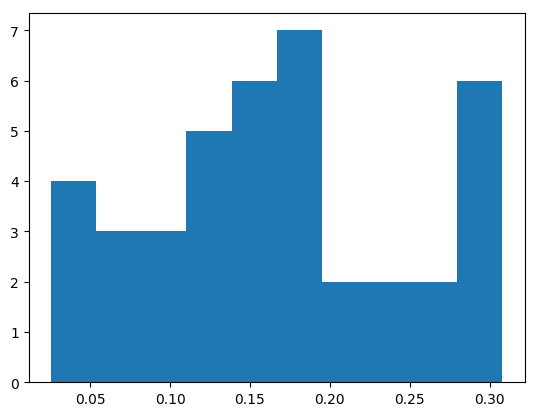

**Case study - betweenness centrality**:

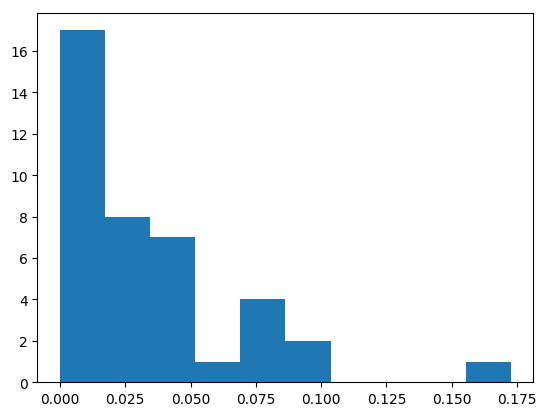

**Case study - MatrixPlot**:

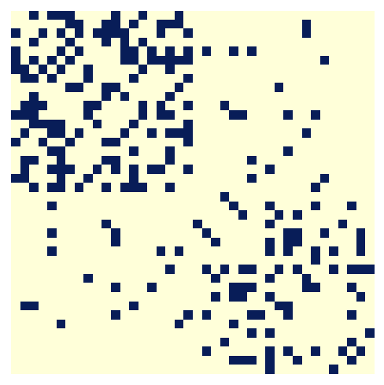

**Case study - ArcPlot**:

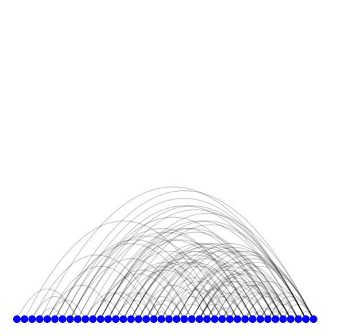

**Case study - CircosPlot**:

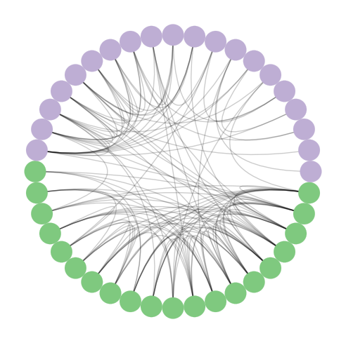

**Case Study - CircosPlot (for largest clique)**:

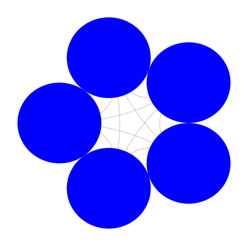

**Case Study - ArcPlot (ordered by degree centrality)**:

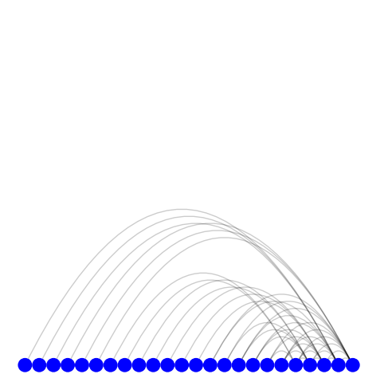

### *Network Analysis in Python (Part II)*

Chapter 1 - Bipartite Graphs and Recommendation Systems

Definitions and basic recap:

- Network/Graph is comprised of two sets - nodes and edges (connections between nodes)
- Undirected graphs (e.g., Facebook) have connections without any direction (“A connects B” and “B connects A” both mean the same thing)
- Directed graphs (e.g., Twitter) have connections with direction (“A connects B” can happen even in the absence of “B connects A”)
- The “networkx” package has a library of functions and API for working with networks and graphs
  - Typically, this is called using “import networkx as nx”
  - For a given graph G, can call G.nodes() and G.edges() to get lists of the relevant data
  - Running type(G) can return Graph, DiGraph, MultiGraph, and MultiDiGraph
- The “nxviz” package has a simple API for visualization of networks in a rational manner
  - Typically, this is called using “import nxviz as nv”
  - Matrix, Arc, Circos, Hive - CircosPlot will be the most used in this course
  - c = nv.CircosPlot(G)
  - c.draw()
  - plt.show()

Bipartite graphs - graphs that are partitioned in to two sets, and with nodes that are only connected to nodes in other partitions:

- Example might be customer nodes and product nodes, where the only connections will be customer/product
- Typically, bipartite data will be encoded in the nodes using the “bipartite” keyword
  - G.add_nodes_from(myListCustomers, bipartite=“customers”)
  - G.add_nodes_from(myListProducts, bipartite=“products”)
  - G.nodes(data=True) # will show the nodes, including their attribute “bipartite”
- “Degree centrality” is defined as # Neighbors / # Possible Neighbors
  - For a bipartite graph, the “Possible Neighbors” are only the nodes in the OTHER partition
  - Typically, list comprehensions are used to gather just the nodes that have one “bipartite”: or the other
  - Can then use this list of nodes from one partition with “nx.bipartite.degree_centrality(G, cust_nodes)”, where cust_nodes is the list of nodes in ONE of the partitions

Bipartite graphs and recommendation systems - extending from unipartite (users-only) to bipartite (repo-users):

- This is a means of recommending repositories for users to work on ; based on set overlap
- Often helpful to use node sets in code for these
  - The command G.neighbors(“myNode”) returns a list of all the neighbors of “myNode”
  - With two lists of nodes, could run set(nodeNeighbor1).intersection(nodeNeighbor3)
  - Alternately, set(nodeNeighbor3).difference(nodeNeighbor1) will return items in nodeNeighbor3 but not in nodeNeighbor1

Example code includes:

```python
# Import necessary modules
import networkx as nx
from nxviz import CircosPlot
import matplotlib.pyplot as plt


# Create a dummy bipartite graph
bpG = nx.Graph()

# Create 200 nodes of projects and 1000 nodes of users
bpProj = list(range(200))
bpUser = list(range(200, 1200))
bpG.add_nodes_from(bpProj, bipartite="projects")
bpG.add_nodes_from(bpUser, bipartite="users")


# Create roughly 10,000 edges (out of 200,000 possible)
# Make some projects much more prolific than others
# Project likelihood = 0.5 for [0-3], 0.25 for [4-9], and Proj / 3000 for all others
import random

for a in bpProj:
    for b in bpUser:
        # Set up the core likelihood based on project (a)
        if a <= 3: baseLike = 0.5
        elif a <= 9: baseLike = 0.25
        else: baseLike = (210-a) / 3000

        # Scale the likelihood by user
        finalLike = baseLike * (b + 300) / 1000
        if finalLike > random.random():
            bpG.add_edge(a, b)


# Add the degree centrality score of each node to their metadata dictionary
G = bpG.copy()
dcs = nx.degree_centrality(G)
for n in G.nodes():
    G.node[n]['centrality'] = dcs[n]

# Create the CircosPlot object: c
c = CircosPlot(G, node_color="bipartite", node_grouping="bipartite", node_order="centrality")

# Draw c to the screen (too time-consuming - large graphic)
# c.draw()

# Display the plot
# plt.show()


# Define get_nodes_from_partition()
def get_nodes_from_partition(G, partition):
    # Initialize an empty list for nodes to be returned
    nodes = []
    # Iterate over each node in the graph G
    for n in G.nodes():
        # Check that the node belongs to the particular partition
        if G.node[n]['bipartite'] == partition:
            # If so, append it to the list of nodes
            nodes.append(n)
    return nodes

# Print the number of nodes in the 'projects' partition
print(len(get_nodes_from_partition(G, "projects")))

# Print the number of nodes in the 'users' partition
print(len(get_nodes_from_partition(G, "users")))


# Import matplotlib
import matplotlib.pyplot as plt

# Get the 'users' nodes: user_nodes
user_nodes = get_nodes_from_partition(G, "users")

# Compute the degree centralities: dcs
dcs = nx.degree_centrality(G)

# Get the degree centralities for user_nodes: user_dcs
user_dcs = [dcs[n] for n in user_nodes]

# Plot the degree distribution of users_dcs
# plt.yscale('log')
plt.hist(user_dcs, bins=20)
# plt.show()
plt.savefig("_dummyPy077.png", bbox_inches="tight")
plt.clf()


# Get the 'projects' nodes: project_nodes
project_nodes = [n for n, d in G.nodes(data=True) if d["bipartite"] == "projects"]

# Compute the degree centralities: dcs
dcs = nx.degree_centrality(G)

# Get the degree centralities for project_nodes: project_dcs
project_dcs = [dcs[n] for n in project_nodes]

# Plot the degree distribution of project_dcs
# plt.yscale('log')
plt.hist(project_dcs, bins=20)
# plt.show()
plt.savefig("_dummyPy078.png", bbox_inches="tight")
plt.clf()


def shared_partition_nodes(G, node1, node2):
    # Check that the nodes belong to the same partition
    assert G.node[node1]['bipartite'] == G.node[node2]['bipartite']

    # Get neighbors of node 1: nbrs1
    nbrs1 = G.neighbors(node1)
    # Get neighbors of node 2: nbrs2
    nbrs2 = G.neighbors(node2)

    # Compute the overlap using set intersections
    overlap = set(nbrs1).intersection(nbrs2)
    return overlap

# Print the number of shared repositories between users 'u7909' and 'u2148'
print(len(shared_partition_nodes(G, 1050, 1100)))


def user_similarity(G, user1, user2, proj_nodes):
    # Check that the nodes belong to the 'users' partition
    assert G.node[user1]['bipartite'] == 'users'
    assert G.node[user2]['bipartite'] == 'users'

    # Get the set of nodes shared between the two users
    shared_nodes = shared_partition_nodes(G, user1, user2)

    # Return the fraction of nodes in the projects partition
    return len(shared_nodes) / len(proj_nodes)

# Compute the similarity score between users 'u4560' and 'u1880'
project_nodes = get_nodes_from_partition(G, "projects")
similarity_score = user_similarity(G, 1050, 1100, project_nodes)

print(similarity_score)


from collections import defaultdict

def most_similar_users(G, user, user_nodes, proj_nodes):
    # Data checks
    assert G.node[user]['bipartite'] == 'users'

    # Get other nodes from user partition
    user_nodes = set(user_nodes)
    user_nodes.remove(user)

    # Create the dictionary: similarities
    similarities = defaultdict(list)
    for n in user_nodes:
        similarity = user_similarity(G, user, n, proj_nodes)
        similarities[similarity].append(n)

    # Compute maximum similarity score: max_similarity
    max_similarity = max(similarities.keys())

    # Return list of users that share maximal similarity
    return similarities[max_similarity]

user_nodes = get_nodes_from_partition(G, 'users')
project_nodes = get_nodes_from_partition(G, 'projects')

print(most_similar_users(G, 1050, user_nodes, project_nodes))


def recommend_repositories(G, from_user, to_user):
    # Get the set of repositories that from_user has contributed to
    from_repos = set(G.neighbors(from_user))
    # Get the set of repositories that to_user has contributed to
    to_repos = set(G.neighbors(to_user))

    # Identify repositories that the from_user is connected to that the to_user is not connected to
    return from_repos.difference(to_repos)

# Print the repositories to be recommended
print(recommend_repositories(G, 1050, 1100))
```

```
## 200
## 1000
## 4
## 0.02
## [729, 818, 1061, 1076, 1137]
## {33, 67, 35, 7, 8, 9, 10, 18, 88}
```

**User Degree Centrality**:

[figure not shown]

**Project Degree Centrality**:

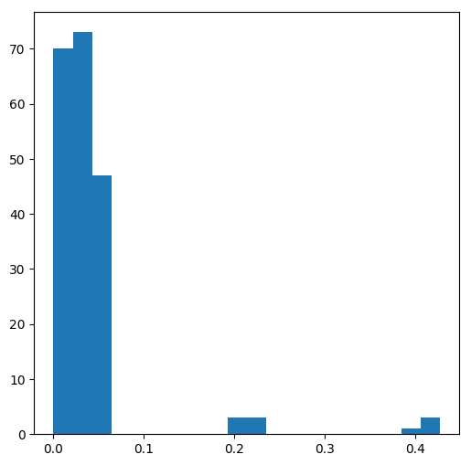

Chapter 2 - Graph projections

Concept of projection - investigating relationships between nodes in one partition CONDITIONAL on connections to nodes in the other partition:

- An example would be that if customer1 and customer2 both bought product3, then customer1 and customer2 could be considered related by means of product3
- Graphs on Disk - flat edge lists ; CSV files (nodelist + metadata , edgelist + metadata)
  - Text file is space-delimited containing Person Club {metadata}
  - A text file like the above can be read in directly using nx.read_edgelist(“myTextFile.txt”)
- Can create a projection provided that one of the node types has already been created as a list
  - G_cust = nx.bipartite.projected_graph(G, cust_nodes)
  - G will have nodes as per cust_nodes and edges as per all common relationships found to the other partition
- Can generate degree centrality in any of three manners
  - nx.bipartite.degree_centrality(G, cust_nodes) # denominator is only the OTHER partition
  - nx.degree_centrality(G) # denominator is everyone other than myself
  - nx.degree_centrality(G_cust) # denominator is everyone in MY partition

Bipartite graphs as matrices - modifications to the MatrixPlot methodology for bipartite graphs:

- Rows - nodes in one partition
- Columns - nodes in other partition
- Cells - 1 if edge exists, 0 if not
- Can be generated using mat = nx.bipartite.biadjacency_matrix(G, row_order=cust_nodes, column_order = prod_nodes)
  - The row_order and column_order are optional, passed if there is reason to want the row/column sorted in a particular manner
  - The matrix returned is of type Sparse Matrix (memory-efficient matrices)
- The projection can be calculated as mat %*% t(mat), where mat is per above
  - The diagonals show the number of connections within the own partition for that node
  - The off-diagonals show the projection based on connections to the other partition
  - Can also run t(mat) %*% mat for the results based on the other of the two partitions
- Matrix multiplication in Python is run using the “@” operator
  - mat.T is the transpose of mat in Python

Representing network data with pandas - human-readable graphs with CSV:

- CSV files have many advantages - human-readable, easy for pandas to work with
  - Primary disadvantage is disk space, as there is repetition that might be avoided in the binary coding for a network/graph
- Node list - each row is one node, with each column being some of the metadata associated to that node
- Edge list - each row is one edge, with each column being some of the metadata associated to that edge
- For pandas, take the data in G.nodes(data=True) and create a dictionary for each node, with the dictionaries being in a list
  - Can use the command dictA.update(dictB) and it will add the elements of dictB to dictA (seems like “append” for dictionaries)
  - Can then run pd.DataFrame(nodeList) and a data frame will be created

Example code includes:

```python
myPath = "./PythonInputFiles/"



import pandas as pd



# Import networkx
import networkx as nx

# Read in the data: g (create from the CSV instead)
# G = nx.read_edgelist('american-revolution.edgelist')

# downloaded file from DataCamp
revMap = pd.read_csv(myPath + "revolution_network_flatfile.txt", index_col=0)
revPeople = list(revMap.index)
revClubs = list(revMap.columns)

G = nx.Graph()
G.add_nodes_from(revPeople + revClubs)

for m in range(revMap.shape[0]):
    for n in range(revMap.shape[1]):
        if revMap.iloc[m, n] == 1: G.add_edge(revPeople[m], revClubs[n])

# Assign nodes to 'clubs' or 'people' partitions
for n, d in G.nodes(data=True):
    if '.' in n:
        G.node[n]["bipartite"] = 'people'
    else:
        G.node[n]["bipartite"] = 'clubs'

# Print the edges of the graph (too many - skip)
# print(G.edges())


# Prepare the nodelists needed for computing projections: people, clubs
people = [n for n in G.nodes() if G.node[n]["bipartite"] == 'people']
clubs = [n for n, d in G.nodes(data=True) if d['bipartite'] == 'clubs']

# Compute the people and clubs projections: peopleG, clubsG
peopleG = nx.bipartite.projected_graph(G, people)
clubsG = nx.bipartite.projected_graph(G, clubs)


import matplotlib.pyplot as plt

# Plot the degree centrality distribution of both node partitions from the original graph
plt.figure()
original_dc = nx.bipartite.degree_centrality(G, people)
plt.hist(list(original_dc.values()), alpha=0.5)
plt.yscale('log')
plt.title('Bipartite degree centrality')
# plt.show()
plt.savefig("_dummyPy079.png", bbox_inches="tight")
plt.clf()


# Plot the degree centrality distribution of the peopleG graph
plt.figure()
people_dc = nx.degree_centrality(peopleG)
plt.hist(list(people_dc.values()))
plt.yscale('log')
plt.title('Degree centrality of people partition')
# plt.show()
plt.savefig("_dummyPy080.png", bbox_inches="tight")
plt.clf()


# Plot the degree centrality distribution of the clubsG graph
plt.figure()
clubs_dc = nx.degree_centrality(clubsG)
plt.hist(list(clubs_dc.values()))
plt.yscale('log')
plt.title('Degree centrality of clubsG partition')
# plt.show()
plt.savefig("_dummyPy081.png", bbox_inches="tight")
plt.clf()


# Copied function from above
# Define get_nodes_from_partition()
def get_nodes_from_partition(G, partition):
    # Initialize an empty list for nodes to be returned
    nodes = []
    # Iterate over each node in the graph G
    for n in G.nodes():
        # Check that the node belongs to the particular partition
        if G.node[n]['bipartite'] == partition:
            # If so, append it to the list of nodes
            nodes.append(n)
    return nodes

# Get the list of people and list of clubs from the graph: people_nodes, clubs_nodes
people_nodes = get_nodes_from_partition(G, "people")
clubs_nodes = get_nodes_from_partition(G, "clubs")


# Requires scipy::sparse
# Compute the biadjacency matrix: bi_matrix
# bi_matrix = nx.bipartite.biadjacency_matrix(G, row_order=people_nodes, column_order=clubs_nodes)

# Compute the user-user projection: user_matrix
# user_matrix = bi_matrix @ bi_matrix.T

# print(user_matrix)


import numpy as np

# Find out the names of people who were members of the most number of clubs
# diag = user_matrix.diagonal()
# indices = np.where(diag == diag.max())[0]
# print('Number of clubs: {0}'.format(diag.max()))
# print('People with the most number of memberships:')
# for i in indices:
#     print('- {0}'.format(people_nodes[i]))

# Set the diagonal to zero and convert it to a coordinate matrix format
# user_matrix.setdiag(0)
# users_coo = user_matrix.tocoo()

# Find pairs of users who shared membership in the most number of clubs
# indices = np.where(users_coo.data == users_coo.data.max())[0]
# print('People with most number of shared memberships:')
# for idx in indices:
#     print('- {0}, {1}'.format(people_nodes[users_coo.row[idx]], people_nodes[users_coo.col[idx]]))


# Initialize a list to store each edge as a record: nodelist
nodelist = []
for n, d in peopleG.nodes(data=True):
    # nodeinfo stores one "record" of data as a dict
    nodeinfo = {'person': n}

    # Update the nodeinfo dictionary
    nodeinfo.update(d)

    # Append the nodeinfo to the node list
    nodelist.append(nodeinfo)


# Create a pandas DataFrame of the nodelist: node_df
node_df = pd.DataFrame(nodelist)
print(node_df.head())


# Initialize a list to store each edge as a record: edgelist
edgelist = []
for n1, n2, d in peopleG.edges(data=True):
    # Initialize a dictionary that shows edge information: edgeinfo
    edgeinfo = {'node1':n1, 'node2':n2}

    # Update the edgeinfo data with the edge metadata
    edgeinfo.update(d)

    # Append the edgeinfo to the edgelist
    edgelist.append(edgeinfo)

# Create a pandas DataFrame of the edgelist: edge_df
edge_df = pd.DataFrame(edgelist)
print(edge_df.head())
```

```
##   bipartite              person
## 0    people          Adams.John
## 1    people        Adams.Samuel
## 2    people            Allen.Dr
## 3    people  Appleton.Nathaniel
## 4    people         Ash.Gilbert
##         node1               node2
## 0  Adams.John  Appleton.Nathaniel
## 1  Adams.John          Swan.James
## 2  Adams.John       Dexter.Samuel
## 3  Adams.John         Symmes.Eben
## 4  Adams.John        Collson.Adam
```

**Revolutionary War Connectivity (Bipartite)**:

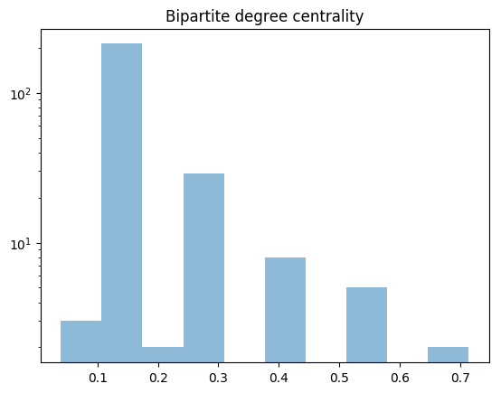

**Revolutionary War Connectivity (People)**:

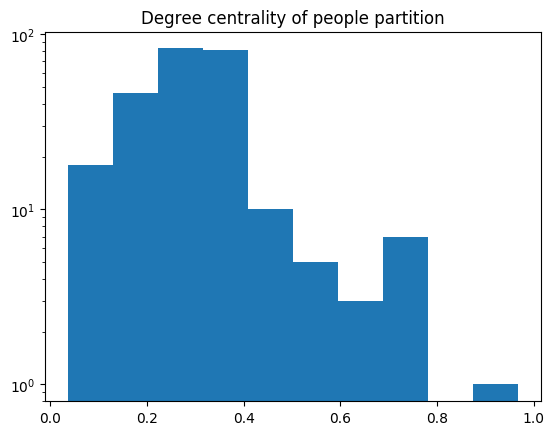

**Revolutionary War Connectivity (Clubs)**:

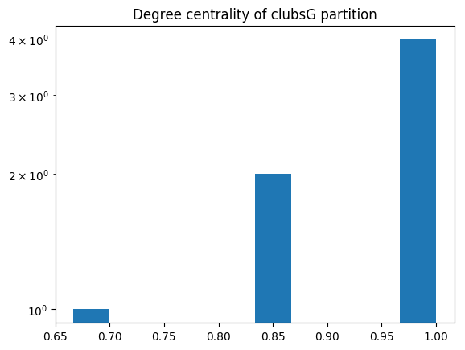

Chapter 3 - Comparing Graphs and Time-Dynamics

Introduction to graph differences - time series analysis (graph statistic over time):

- Evolving graphs - example is a communication network, which dynamically changes over time
  - Could be constant nodes with evolving edges - easier to analyze
  - Could be evolving nodes with evolving edges
- Frequently, the simplifying assumption is made of constant nodes with evolving edges - so, “differences” means “change in edge sets”
  - set(a).difference(set(b)) # will identify any items in a that are not in b
  - Can also run nx.difference(G1, G2), which assumes constant nodes but evolving edges (will do things in G1 but not in G2)

Evolving graph statistics - essentially, change in summary statistics (edges, degree centrality, degree distribution, activity spikes, etc.) over time:

- For simple metrics, can use the edgelist data
- For graph theoretic metrics, use the graph object
- The ECDF (cumulative distribution function - normed and cumulative) is a compact way to represent many time periods in a single plot

Zooming in and zooming out - overall graph summary vs. local graph summary:

- Zooming on nodes involves 1) isolating a given set of nodes, and 2) plotting a node statistic over time
- Example would be to analyze how purchasing patterns have changed over time
  - Suppose that we want to run a deep-dive on noi=“customer1” over a set of graphs Gs[.]
  - degs = []
  - for g in Gs : degs.append(len(g.neighbors(noi)))
- Default dictionaries - defaultdict()
  - from collections import defaultdict
  - d = defaultdict(list)
  - d[“heathrow”].append(0.31) ; d[“heathrow”].append(0.84)
  - d # defaultdict(, {“heathrow” : [0.31, 0.84]})
  - The main difference of a defaultdict() vs a dict() is that defaultdict() allows for appending to a key that does not yet exist (will create as the first item) rather than crashing out

Example code includes:

```python
myPath = "./PythonInputFiles/"


# Dummy up some data with senders and recipients, each being paired to each other at different times
sendList = ["S" + str(x) for x in range(200)]
receiveList = ["R" + str(x) for x in range(200)]

# Allow for 20,000 messages total, pulled at random and with random months
import numpy as np
import pandas as pd

dataSend = np.random.choice(sendList, 20000)
dataReceive = np.random.choice(receiveList, 20000)
dataMonth = np.random.choice(range(4, 11), 20000, p=[0.025, 0.05, 0.075, 0.125, 0.175, 0.225, 0.325])

data = pd.DataFrame( {"sender":dataSend, "recipient":dataReceive, "month":dataMonth} ).drop_duplicates()
print(data.info())
print(data.head())



import networkx as nx

months = range(4, 11)

# Initialize an empty list: Gs
Gs = []

for month in months:
    # Instantiate a new undirected graph: G
    G = nx.Graph()

    # Add in all nodes that have ever shown up to the graph
    G.add_nodes_from(data["sender"])
    G.add_nodes_from(data["recipient"])

    # Filter the DataFrame so that there's only the given month
    df_filtered = data[data['month'] == month]

    # Add edges from filtered DataFrame
    G.add_edges_from(zip(df_filtered["sender"], df_filtered["recipient"]))

    # Append G to the list of graphs
    Gs.append(G)

print(len(Gs))


import networkx as nx
# Instantiate a list of graphs that show edges added: added
added = []
# Instantiate a list of graphs that show edges removed: removed
removed = []
# Here's the fractional change over time
fractional_changes = []
window = 1
i = 0

for i in range(len(Gs) - window):
    g1 = Gs[i]
    g2 = Gs[i + window]

    # Compute graph difference here
    added.append(nx.difference(g2, g1))
    removed.append(nx.difference(g1, g2))

    # Compute change in graph size over time
    fractional_changes.append((len(g2.edges()) - len(g1.edges())) / len(g1.edges()))

    i += 1

# Print the fractional change
print(fractional_changes)


# Import matplotlib
import matplotlib.pyplot as plt

fig = plt.figure()
ax1 = fig.add_subplot(111)

# Plot the number of edges added over time
edges_added = [len(g.edges()) for g in added]
plot1 = ax1.plot(edges_added, label='added', color='orange')

# Plot the number of edges removed over time
edges_removed = [len(g.edges()) for g in removed]
plot2 = ax1.plot(edges_removed, label='removed', color='purple')

# Set yscale to logarithmic scale
ax1.set_yscale('log')
ax1.legend()

# 2nd axes shares x-axis with 1st axes object
ax2 = ax1.twinx()

# Plot the fractional changes over time
plot3 = ax2.plot(fractional_changes, label='fractional change', color='green')

# Here, we create a single legend for both plots
lines1, labels1 = ax1.get_legend_handles_labels()
lines2, labels2 = ax2.get_legend_handles_labels()
ax2.legend(lines1 + lines2, labels1 + labels2, loc=0)
plt.axhline(0, color='green', linestyle='--')
# plt.show()
plt.savefig("_dummyPy082.png", bbox_inches="tight")
plt.clf()


# Import matplotlib
import matplotlib.pyplot as plt

fig = plt.figure()

# Create a list of the number of edges per month
edge_sizes = [len(g.edges()) for g in Gs]

# Plot edge sizes over time
plt.plot(edge_sizes)
plt.xlabel('Time elapsed from first month (in months).')
plt.ylabel('Number of edges')
# plt.show()
plt.savefig("_dummyPy083.png", bbox_inches="tight")
plt.clf()


# Create a list of degree centrality scores month-by-month
cents = []
for G in Gs:
    cent = nx.degree_centrality(G)
    cents.append(cent)

# Create a function for ECDF (copy from statistics)
def ECDF(myData):
    """Compute ECDF for a one-dimensional array of measurements."""

    # Number of data points: n
    n = len(myData)

    # x-data for the ECDF: x
    x = np.sort(myData)

    # y-data for the ECDF: y
    y = np.arange(1, n+1) / n

    return x, y


# Plot ECDFs over time
fig = plt.figure()
for i in range(len(cents)):
    x, y = ECDF(list(cents[i].values()))
    plt.plot(x, y, label='Month {0}'.format(i+1))

plt.legend()
# plt.show()
plt.savefig("_dummyPy084.png", bbox_inches="tight")
plt.clf()


# Get the top 5 unique degree centrality scores: top_dcs
top_dcs = sorted(set(nx.degree_centrality(G).values()), reverse=True)[0:5]

# Create list of nodes that have the top 5 highest overall degree centralities
top_connected = []
for n, dc in nx.degree_centrality(G).items():
    if dc in top_dcs:
        top_connected.append(n)

# Print the number of nodes that share the top 5 degree centrality scores
print(len(top_connected))


# Import necessary modules
import matplotlib.pyplot as plt
from collections import defaultdict

# Create a defaultdict in which the keys are nodes and the values are a list of connectivity scores over time
connectivity = defaultdict(list)
for n in top_connected:
    for g in Gs:
        connectivity[n].append(len(g.neighbors(n)))

# Plot the connectivity for each node
fig = plt.figure()
for n, conn in connectivity.items():
    plt.plot(conn, label=n)

plt.legend()
# plt.show()
plt.savefig("_dummyPy085.png", bbox_inches="tight")
plt.clf()
```

```
## <class 'pandas.core.frame.DataFrame'>
## Int64Index: 18949 entries, 0 to 19999
## Data columns (total 3 columns):
## month        18949 non-null int32
## recipient    18949 non-null object
## sender       18949 non-null object
## dtypes: int32(1), object(2)
## memory usage: 370.1+ KB
## None
##    month recipient sender
## 0      8       R26    S14
## 1     10        R8    S97
## 2      5      R189   S128
## 3      7      R133    S79
## 4      5      R169    S75
## 7
## [1.07098121085595, 0.46774193548387094, 0.6133241758241759, 0.4653043848446147, 0.22806507844276583, 0.4203927135083984]
## 8
```

**Evolution of Edges Added and Deleted**:

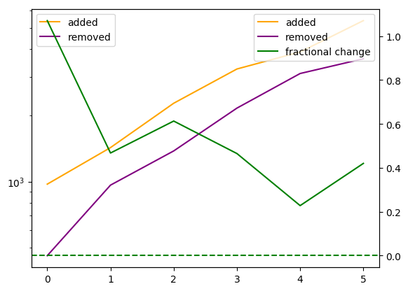

**Evolution of Total Number of Edges**:

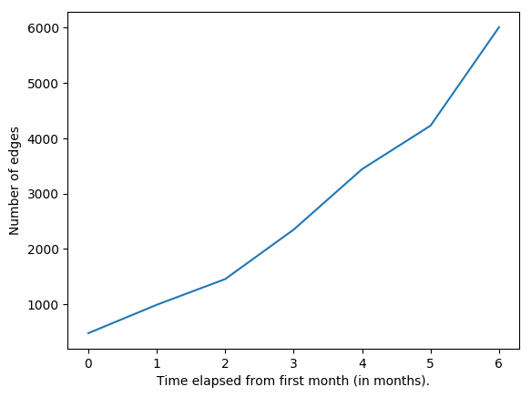

**Evolution of ECDF for Degree Centrality**:

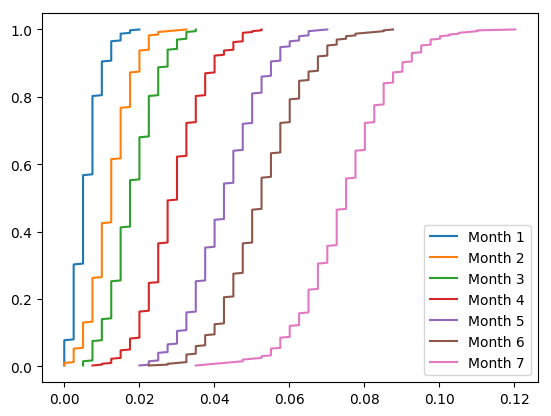

**Evolution of Edges for Most Connected Users**:

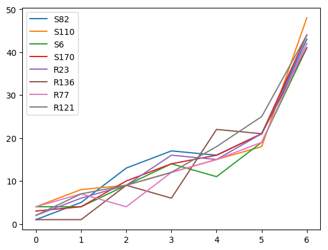

Chapter 4 - Case Study (Tying Together)

Introduction to the dataset - 6 months worth of student postings to college forums:

- The nodes are bipartite (students and forums), with edges existing when a student posts to a forum
  - Constructing a graph from a pandas DataFrame
  - Constructing unipartite projections of a bipartite graph
  - Visualization using CircosPlot
  - Time series filtering and analysis
- Graphs from DataFrames - G = nx.Graph() ; G.add_nodes_from(df[“products”], bipartite=“products”)
  - G.add_edges_from(zip(df[“customers”], df[“products”]))
- Bipartite projections to unipartite - cust_nodes = [n for n in G.nodes() if G.node[n][“bipartite”] == “customers”]
  - nx.bipartite.projected_graph(g, nodes = cust_nodes)

Time-based filtering - including the datetime module:

- Filtering edges - for example, [(u, v) for u, v, d in G.edges(data=True) if d[“sale count”] >= 10]
- Using datetime - from datetime import datetime, timedelta
  - date1 = datetime(2011, 11, 6) # will form 2011-11-6
- Plotting - c = CircosPlot(G, node_grouping=“bipartite”, node_color=“bipartite”) ; c.draw() ; plt.show()

Time series analysis - global vs. local (point in time) analysis:

- The timedelta object from datetime allows for calculating time between two datetime
  - td=timedelta(4) ; datetime.datetime(2011, 11, 10, 0, 0) + td = datetime.datetime(2011, 11, 14, 0, 0)
- Degree centrality is nx.degree_centrality(G)
  - For the bipartite (denominator only the OTHER partition), use nx.bipartite.degree_centrality(G, nodeType1List)

Example code includes:

```python
myPath = "./PythonInputFiles/"



import pickle
import pandas as pd
import networkx as nx


# Downloaded key file "uci-forum.p" from DataCamp
with open(myPath + "uci-forum.p", "rb") as pFile: tmpGraph = pickle.load(pFile)

# Convert to a DataFrame with student-forum-date
# Grab the student-forum-date matches from the edges
edgeData = tmpGraph.edges(data=True)
studentData = [x[0] if x[0][0]=="s" else x[1] for x in edgeData]
forumData = [x[1] if x[0][0]=="s" else x[0] for x in edgeData]
dateData = pd.to_datetime([x[2]["date"] for x in edgeData])

# Check that the student data matches the nodes with bipartite="student"
studentNodes = set([x for x in tmpGraph.nodes() if tmpGraph.node[x]["bipartite"]=="student"])
forumNodes = set([x for x in tmpGraph.nodes() if tmpGraph.node[x]["bipartite"]=="forum"])

studentNodes.difference(set(studentData))
forumNodes.difference(set(forumData))
set(studentData).difference(studentNodes)
set(forumData).difference(forumNodes)

# Create the DataFrame
data = pd.DataFrame( {"student":studentData, "forum":forumData, "date":dateData} )
data.info()
data.head(10)




# Instantiate a new Graph: G
G = nx.Graph()

# Add nodes from each of the partitions
G.add_nodes_from(data["student"], bipartite="student")
G.add_nodes_from(data["forum"], bipartite="forum")

# Add in each edge along with the date the edge was created
for r, d in data.iterrows():
    G.add_edge(d["student"], d["forum"], date=d["date"])


# Import necessary modules
import matplotlib.pyplot as plt
import networkx as nx

# Get the student partition's nodes: student_nodes
student_nodes = [n for n, d in G.nodes(data=True) if d['bipartite'] == 'student']

# Create the students nodes projection as a graph: G_students
G_students = nx.bipartite.projected_graph(G, nodes=student_nodes)

# Calculate the degree centrality using nx.degree_centrality: dcs
dcs = nx.degree_centrality(G_students)

# Plot the histogram of degree centrality values
plt.hist(list(dcs.values()))
plt.yscale('log')
# plt.show()
plt.savefig("_dummyPy086.png", bbox_inches="tight")
plt.clf()


# Import necessary modules
import matplotlib.pyplot as plt
import networkx as nx

# Get the forums partition's nodes: forum_nodes
forum_nodes = [n for n, d in G.nodes(data=True) if d["bipartite"] == "forum"]

# Create the forum nodes projection as a graph: G_forum
G_forum = nx.bipartite.projected_graph(G, forum_nodes)

# Calculate the degree centrality using nx.degree_centrality: dcs
dcs = nx.degree_centrality(G_forum)

# Plot the histogram of degree centrality values
plt.hist(list(dcs.values()))
plt.yscale('log')
# plt.show()
plt.savefig("_dummyPy087.png", bbox_inches="tight")
plt.clf()


import networkx as nx
from datetime import datetime

# Instantiate a new graph: G_sub
G_sub = nx.Graph()

# Add nodes from the original graph
G_sub.add_nodes_from(G.nodes(data=True))

# Add edges using a list comprehension with one conditional on the edge dates, that the date of the edge is earlier than 2004-05-16.
G_sub.add_edges_from([(u, v, d) for u, v, d in G.edges(data=True) if d['date'] < datetime(2004, 5, 16)])


# Import necessary modules
from nxviz import CircosPlot
import networkx as nx
import matplotlib.pyplot as plt

# Compute degree centrality scores of each node
dcs = nx.bipartite.degree_centrality(G, nodes=forum_nodes)
for n, d in G_sub.nodes(data=True):
    G_sub.node[n]['dc'] = dcs[n]

# Create the CircosPlot object: c
c = CircosPlot(G_sub, node_color = "bipartite", node_grouping="bipartite", node_order="dc")

# Draw c to screen
c.draw()

# Display the plot
# plt.show()
plt.savefig("_dummyPy088.png", bbox_inches="tight")
plt.clf()


from datetime import datetime
dayone = datetime(2004, 5, 14, 0, 0)
lastday = datetime(2004, 10, 26, 0, 0)

# Import necessary modules
from datetime import timedelta
import matplotlib.pyplot as plt

# Define current day and timedelta of 2 days
curr_day = dayone
td = timedelta(days=2)

# Initialize an empty list of posts by day
n_posts = []
while curr_day < lastday:
    if curr_day.day == 1:
        print(curr_day)
    # Filter edges such that they are within the sliding time window: edges
    edges = [(u, v, d) for u, v, d in G.edges(data=True) if d['date'] >= curr_day and d['date'] < curr_day + td]

    # Append number of edges to the n_posts list
    n_posts.append(len(edges))

    # Increment the curr_day by the time delta
    curr_day += td

# Create the plot
plt.plot(n_posts)
plt.xlabel('Days elapsed')
plt.ylabel('Number of posts')
# plt.show()
plt.savefig("_dummyPy089.png", bbox_inches="tight")
plt.clf()


from datetime import datetime, timedelta
import numpy as np
import networkx as nx
import matplotlib.pyplot as plt

# Initialize a new list: mean_dcs
mean_dcs = []
curr_day = dayone
td = timedelta(days=2)

while curr_day < lastday:
    if curr_day.day == 1:
        print(curr_day)
    # Instantiate a new graph containing a subset of edges: G_sub
    G_sub = nx.Graph()
    # Add nodes from G
    G_sub.add_nodes_from(G.nodes(data=True))
    # Add in edges that fulfill the criteria
    G_sub.add_edges_from([(u, v, d) for u, v, d in G.edges(data=True) if d['date'] >= curr_day and d['date'] < curr_day + td])

    # Get the students projection
    G_student_sub = nx.bipartite.projected_graph(G_sub, student_nodes)
    # Compute the degree centrality of the students projection
    dc = nx.degree_centrality(G_student_sub)
    # Append mean degree centrality to the list mean_dcs
    mean_dcs.append(np.mean(list(dc.values())))
    # Increment the time
    curr_day += td

plt.plot(mean_dcs)
plt.xlabel('Time elapsed')
plt.ylabel('Degree centrality.')
# plt.show()
plt.savefig("_dummyPy090.png", bbox_inches="tight")
plt.clf()


# Import necessary modules
from datetime import timedelta
import networkx as nx
import matplotlib.pyplot as plt

# Instantiate a list to hold the list of most popular forums by day: most_popular_forums
most_popular_forums = []
# Instantiate a list to hold the degree centrality scores of the most popular forums: highest_dcs
highest_dcs = []
curr_day = dayone
td = timedelta(days=1)

while curr_day < lastday:
    if curr_day.day == 1:
        print(curr_day)
    # Instantiate new graph: G_sub
    G_sub = nx.Graph()

    # Add in nodes from original graph G
    G_sub.add_nodes_from(G.nodes(data=True))

    # Add in edges from the original graph G that fulfill the criteria
    G_sub.add_edges_from([(u, v, d) for u, v, d in G.edges(data=True) if d['date'] >= curr_day and d['date'] < curr_day + td])

    # CODE CONTINUES ON NEXT EXERCISE
    curr_day += td


# Import necessary modules
from datetime import timedelta
import networkx as nx
import matplotlib.pyplot as plt

most_popular_forums = []
highest_dcs = []
curr_day = dayone
td = timedelta(days=1)

while curr_day < lastday:
    if curr_day.day == 1:
        print(curr_day)
    G_sub = nx.Graph()
    G_sub.add_nodes_from(G.nodes(data=True))
    G_sub.add_edges_from([(u, v, d) for u, v, d in G.edges(data=True) if d['date'] >= curr_day and d['date'] < curr_day + td])

    # Get the degree centrality
    dc = nx.bipartite.degree_centrality(G_sub, forum_nodes)
    # Filter the dictionary such that there's only forum degree centralities
    forum_dcs = {n:dc for n, dc in dc.items() if n in forum_nodes}
    # Identify the most popular forum(s)
    most_popular_forum = [n for n, dc in forum_dcs.items() if dc == max(forum_dcs.values()) and dc != 0]
    most_popular_forums.append(most_popular_forum)
    # Store the highest dc values in highest_dcs
    highest_dcs.append(max(forum_dcs.values()))

    curr_day += td

plt.figure(1)
plt.plot([len(forums) for forums in most_popular_forums], color='blue', label='Forums')
plt.ylabel('Number of Most Popular Forums')
# plt.show()
plt.savefig("_dummyPy091.png", bbox_inches="tight")
plt.clf()


plt.figure(2)
plt.plot(highest_dcs, color='orange', label='DC Score')
plt.ylabel('Top Degree Centrality Score')
# plt.show()
plt.savefig("_dummyPy092.png", bbox_inches="tight")
plt.clf()
```

[output not shown]

**Degree Centrality (Student)**:

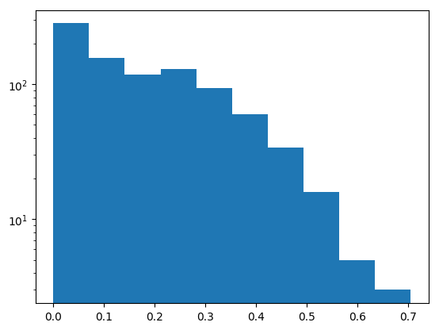

**Degree Centrality (Forum)**:

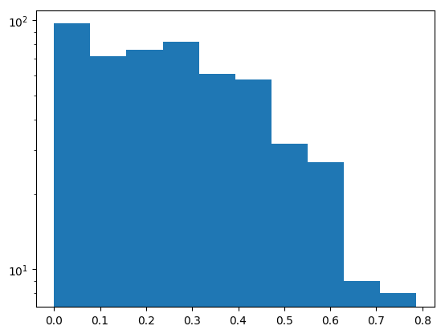

**Circos Plot of Student-Forum Database**:

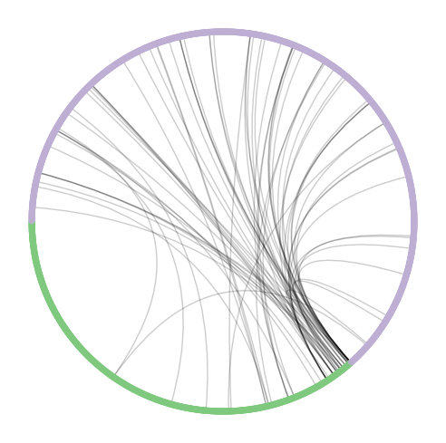

**Evolution of Posting**:

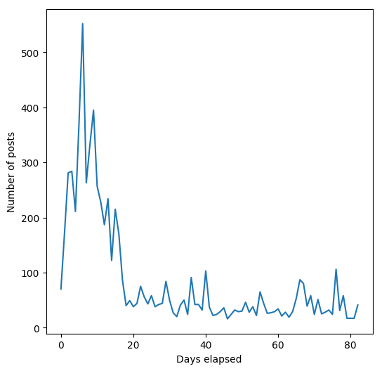

**Evolution of Degree Centrality**:

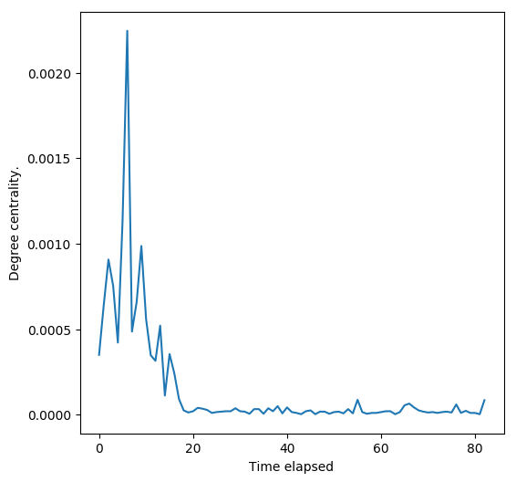

**Most Popular Forum Concentrations**:

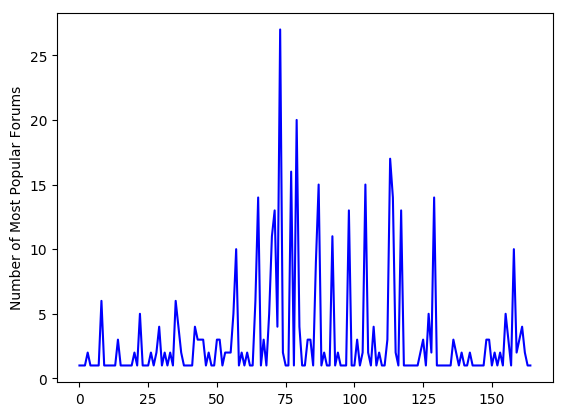

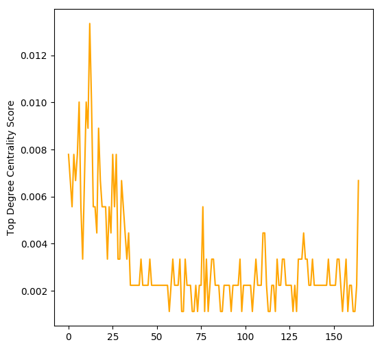